# OPFs v2

February 3rd, 2016

## OPFs:

### What:

- Operational protein families are clusters of similar proteins
- Creating OPFs is a database free method of grouping sequences
- Analogous to OTUs

### Why:

Databases are not great

- Genes present are limited to what we "know" or at least have seen before
- Annotations are limited in the same way
- Leaves a large (often over half) of the data in a black box

## Quickly:

1. Assemble
2. ORF/gene prediction
3. Get counts
4. All v all BLAST
5. Cluster

## Estimate gene counts

Map reads with bowtie (and normalize)

### Counts file

- Use bowtie to map reads to genes
- Normalize by sequence length

```
ceiling(num_reads_mapped * 100 / len(gene))
```

## Creating OPFs

### BLAST

All v all

Blast all genes against each other (proteins, blastp)

```
-max_target_seqs 10000
```

### Cluster

mg-cluster with mothur

```
mgcluster(blast=allVall100.out, count=allgenes.counts)
```

## Datasets

1. Obesity in twins (Turnbaugh et al. 2009)
   - 18 metagenomes from lean and obese twin pairs and their mothers
   - From MG-RAST
2. Pregnancy (Koren et al. 2012)
   - 20 metagenomes from mothers during the first and third trimester of pregnancy
   - From NCBI (MG-RAST data is messed up and being fixed with zero urgency)

## Datasets

HMP data

- Anterior nares
  - 87 metagenomes
- Buccal mucosa
  - 107 metagenomes
- Posterior fornix
  - 51 metagenomes
- Supragingival plaque
  - 118 metagenomes
- Stool
  - 138 metagenomes
- Tongue dorsum
  - 128 metagenomes

## Twin data

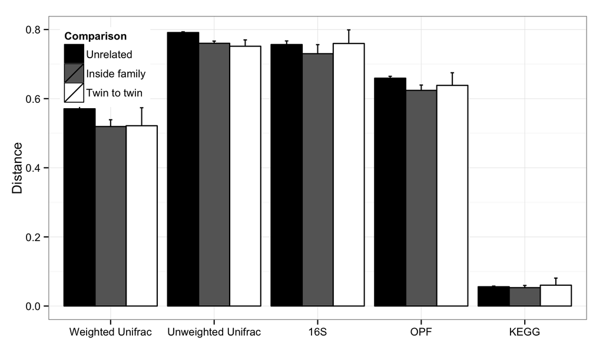

## Pregnancy data

KEGG masks variation, notice scale

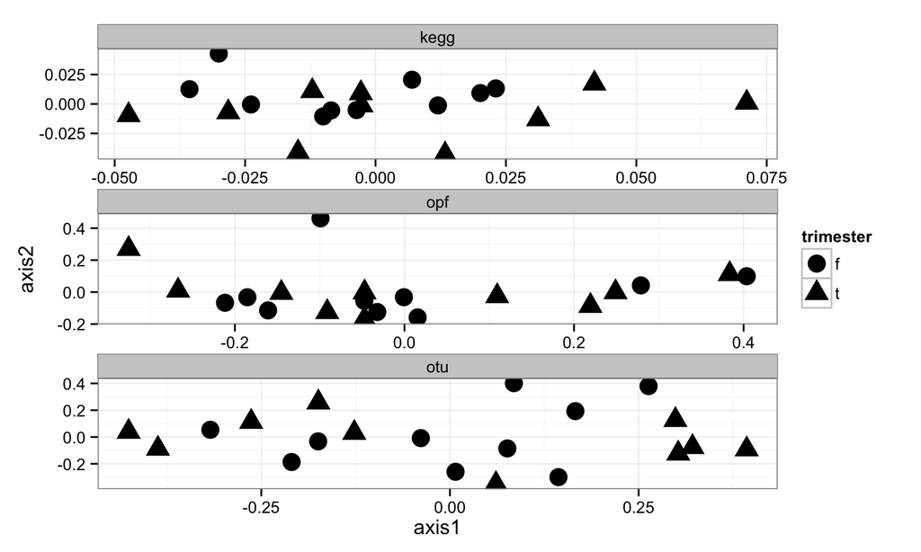

## HMP Anterior nares

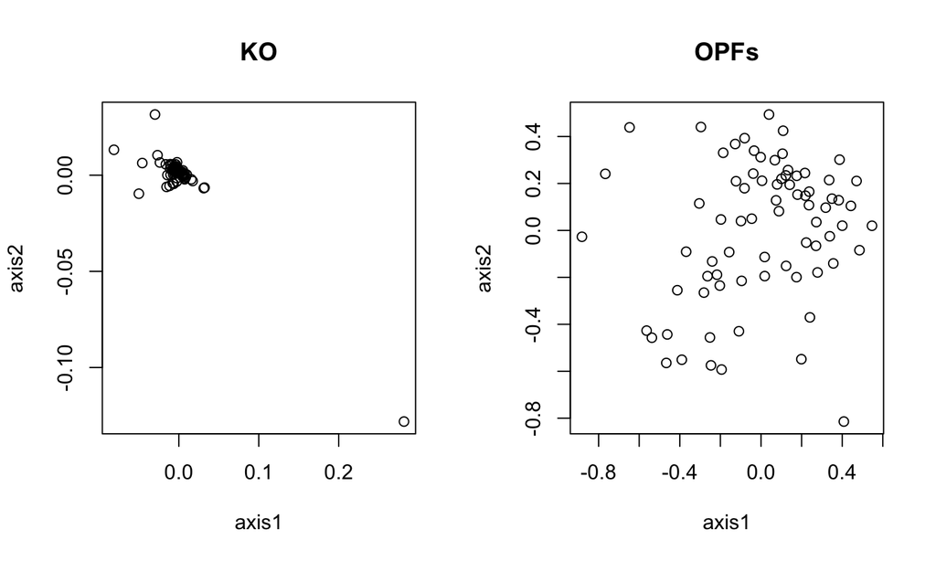

## HMP Posterior fornix

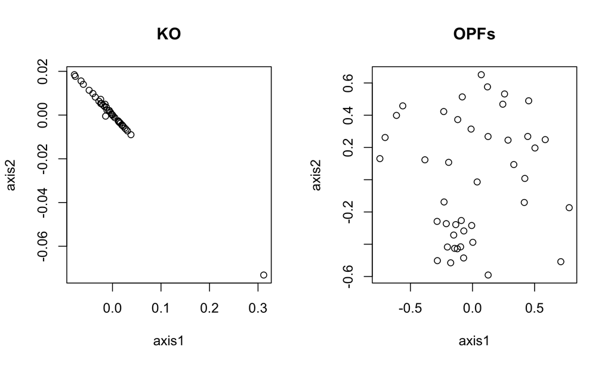

## HMP Buccal mucosa

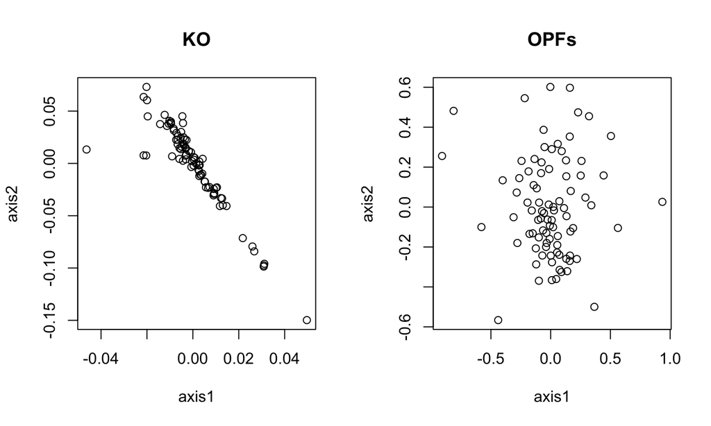

## Where do we go from here?

- OPFs are a unit
- As an OTU analog can do similar analysis
- Re-purpose diversity metrics
- OPF prediction and feature selection